# 03exercisesClustering

Sebastian Sternberg & Marcel Neunhoeffer

27 March 2019

Clustering practical session - Learn how to use k-means and hierarchical clustering in R - Apply both techniques to Immoscout data - Learn about different approaches for cluster validation - Apply clustering as a data pre-processing step

```r
#empty workspace
rm(list = ls())
```

# K-means clustering

The function kmeans() performs K-means clustering in R. We begin with kmeans() a simple simulated example in which there truly are two clusters in the data: the first 25 observations have a mean shift relative to the next 25 observations (Example taken from James et atl. (2013)).

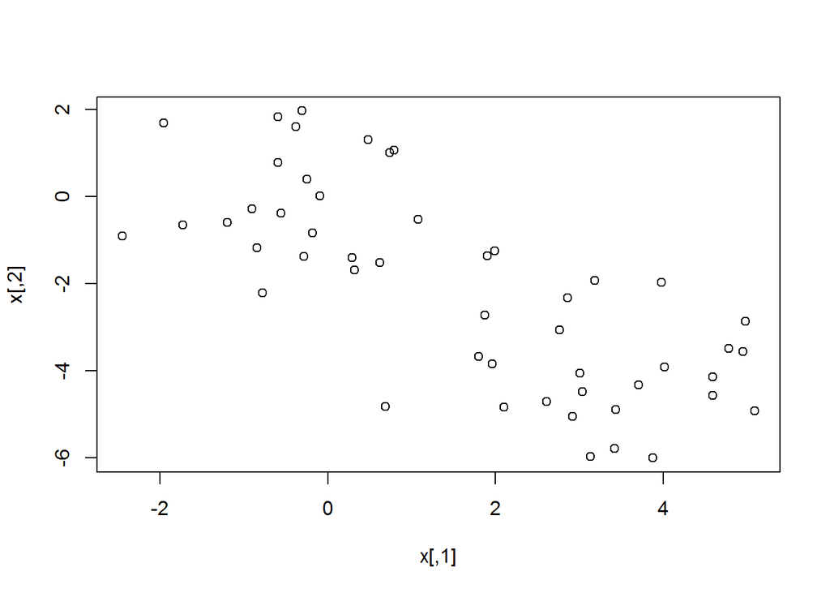

```r
set.seed (2)

x <- matrix(rnorm (50*2), ncol =2)
x[1:25 ,1] <- x[1:25, 1]+3
x[1:25 ,2] <- x[1:25, 2] -4

plot(x)
```

We now perform K-means clustering with K = 2.

```r
km_out <- kmeans(x,
                  centers =  2, #two clusters
                  nstart = 20)
km_out
```

```
## K-means clustering with 2 clusters of sizes 25, 25
##
## Cluster means:
##         [,1]       [,2]
## 1 -0.1956978 -0.1848774
## 2  3.3339737 -4.0761910
##
## Clustering vector:
##  [1] 2 2 2 2 2 2 2 2 2 2 2 2 2 2 2 2 2 2 2 2 2 2 2 2 2 1 1 1 1 1 1 1 1 1 1
## [36] 1 1 1 1 1 1 1 1 1 1 1 1 1 1 1
##
## Within cluster sum of squares by cluster:
## [1] 65.40068 63.20595
##  (between_SS / total_SS =  72.8 %)
##
## Available components:
##
## [1] "cluster"      "centers"      "totss"        "withinss"
## [5] "tot.withinss" "betweenss"    "size"         "iter"
## [9] "ifault"
```

```r
km_out$cluster #A vector of integers (from 1:k) indicating the cluster to which each point is allocated
```

```
##  [1] 2 2 2 2 2 2 2 2 2 2 2 2 2 2 2 2 2 2 2 2 2 2 2 2 2 1 1 1 1 1 1 1 1 1 1
## [36] 1 1 1 1 1 1 1 1 1 1 1 1 1 1 1
```

```r
km_out$tot.withinss #total within-cluster sum of squares, i.e. sum(withinss)
```

```
## [1] 128.6066
```

```r
km_out$size #The number of points in each cluster
```

```
## [1] 25 25
```

The K-means clustering perfectly separated the observations into two clusters even though we did not supply any group information to kmeans(). We can plot the data, with each observation colored according to its cluster assignment.

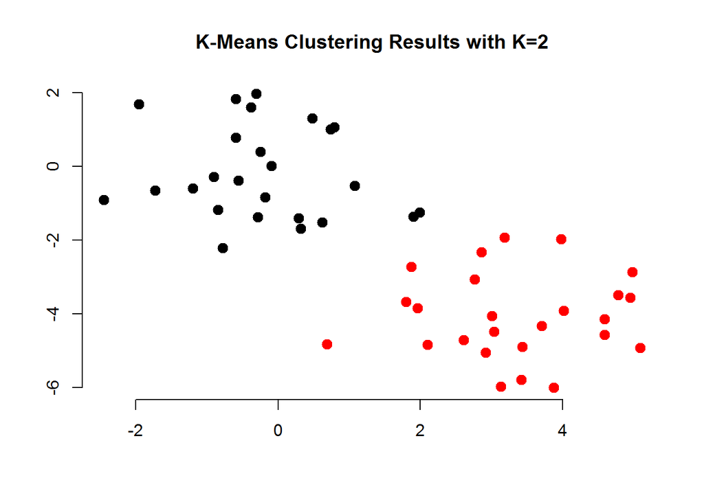

```r
plot(x,
     col = km_out$cluster ,
main="K-Means Clustering Results with K=2",
xlab = "",
ylab= "",
pch = 20,
cex = 2,
bty = "n")
```

Here the observations can be easily plotted because they are two-dimensional. If there were more than two variables then we could instead perform PCA and plot the first two principal components score vectors (more on that later).

In this example, we knew that there really were two clusters because we generated the data. However, for real data, in general we do not know the true number of clusters. We could instead have performed K-means clustering on this example with K = 3.

```r
set.seed(1234)

km_out3 <- kmeans(x, 3, nstart = 20)
km_out3$cluster
```

```
##  [1] 1 2 1 2 1 1 1 2 1 2 1 2 1 2 1 2 1 1 1 1 1 2 1 1 1 3 3 3 3 3 3 3 3 3 3
## [36] 3 3 3 3 3 3 3 3 2 3 2 3 3 3 3
```

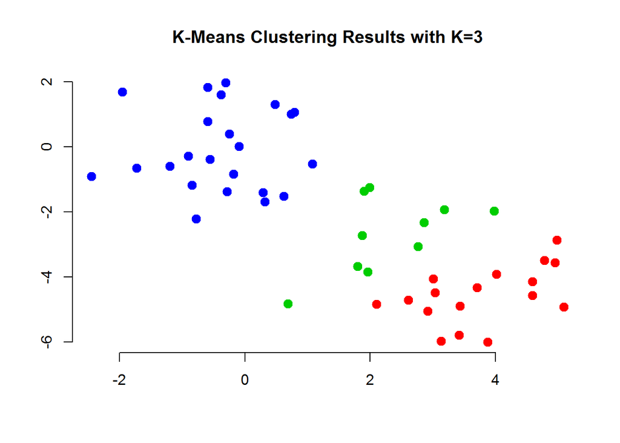

```r
plot(x,
     col =(km_out3$cluster +1) ,
main="K-Means Clustering Results with K=3",
xlab ="",
ylab="",
pch =20,
cex = 2,
bty = "n")
```

K-Means will always find the desired number of clusters:

```r
set.seed(1234)

km_out5 <- kmeans(x, 5, nstart = 20)
km_out5$cluster
```

```
##  [1] 2 3 5 3 2 2 5 3 5 3 2 3 2 2 5 2 2 2 5 2 5 2 5 5 2 4 1 1 1 4 1 4 4 4 4
## [36] 1 4 4 4 1 1 1 4 3 4 3 1 4 4 4
```

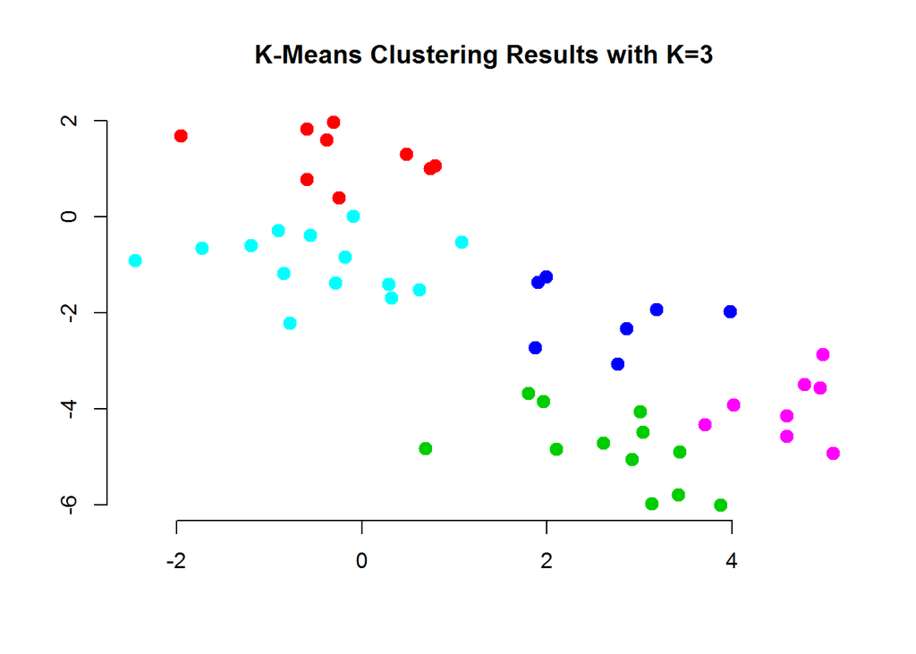

```r
plot(x,
     col =(km_out5$cluster +1) ,
main="K-Means Clustering Results with K=3",
xlab ="",
ylab="",
pch =20,
cex = 2,
bty = "n")
```

As pointed out in the presentation, different initial starting values can lead to different cluster assignments. To validate our solution, we can use the nstart parameter in the kmeans function.

The nstart option attempts multiple initial configurations and reports on the best one. For example, adding nstart=25 will generate 25 initial random centroids and choose the best one for the algorithm.

```r
set.seed(123)
km_out <- kmeans (x,3, nstart =1)
km_out$tot.withinss
```

```
## [1] 104.3319
```

```r
set.seed(123)
km_out <- kmeans (x,3, nstart =20)
km_out$tot.withinss
```

```
## [1] 97.97927
```

```r
set.seed(123)
km_out <- kmeans (x,3, nstart =50)
km_out$tot.withinss
```

```
## [1] 97.97927
```

Note that *km_out$tot.withinss* is the total within-cluster sum of squares, which we seek to minimize by performing K-means clustering.

It is strongly recommended always running K-means clustering with a large value of nstart, such as 20 or 50, since otherwise undesirable local optimum may be obtained. The default of nstart in the k-means function is 1. Since K-means cluster analysis starts with k randomly chosen centroids, a different solution can be obtained each time the function is invoked. Use the set.seed() function to guarantee that the results are reproducible.

# Hclust

In R, the hclust() function implements hierarchical clustering.

We use the same fake data as before.

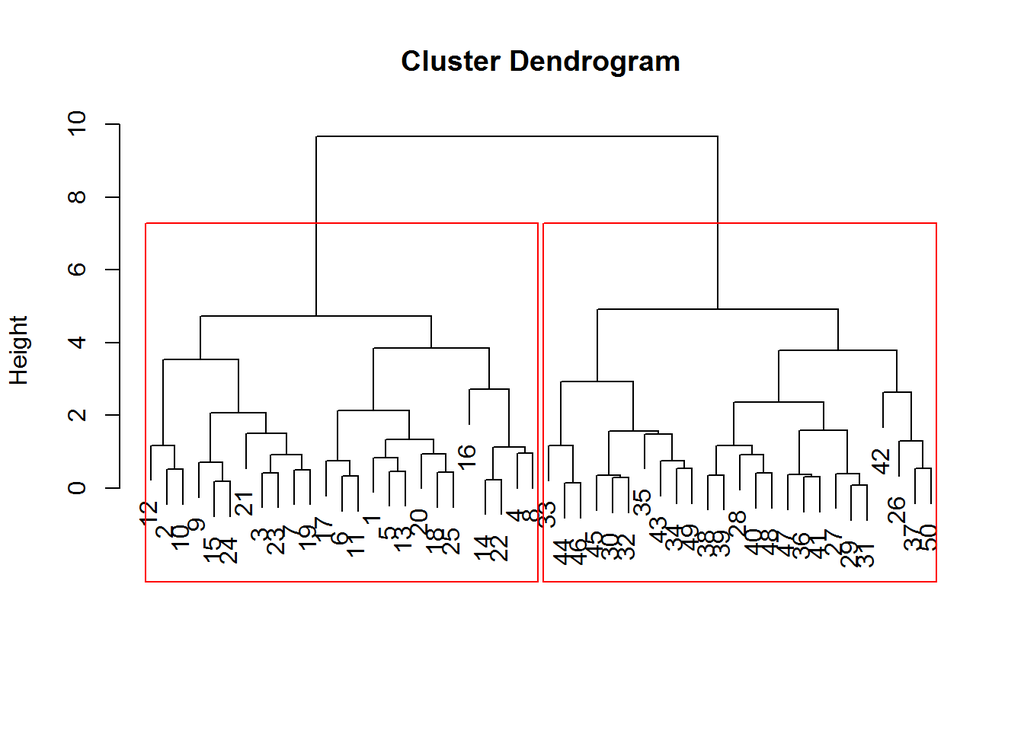

```r
hc.complete <- hclust (dist(x), method ="complete")
# plot the dendogram
plot(hc.complete,
     xlab = "",
     sub = "")
# draw red borders around the 2 clusters
rect.hclust(hc.complete, k=2, border="red")
```

It is very simple to change the linkage:

```r
#average linkage
hc.average <- hclust (dist(x), method ="average")

#single linkage
hc.single <- hclust (dist(x), method ="single")
```

We can now plot the dendrograms obtained using the usual plot() function. The numbers at the bottom of the plot identify each observation.

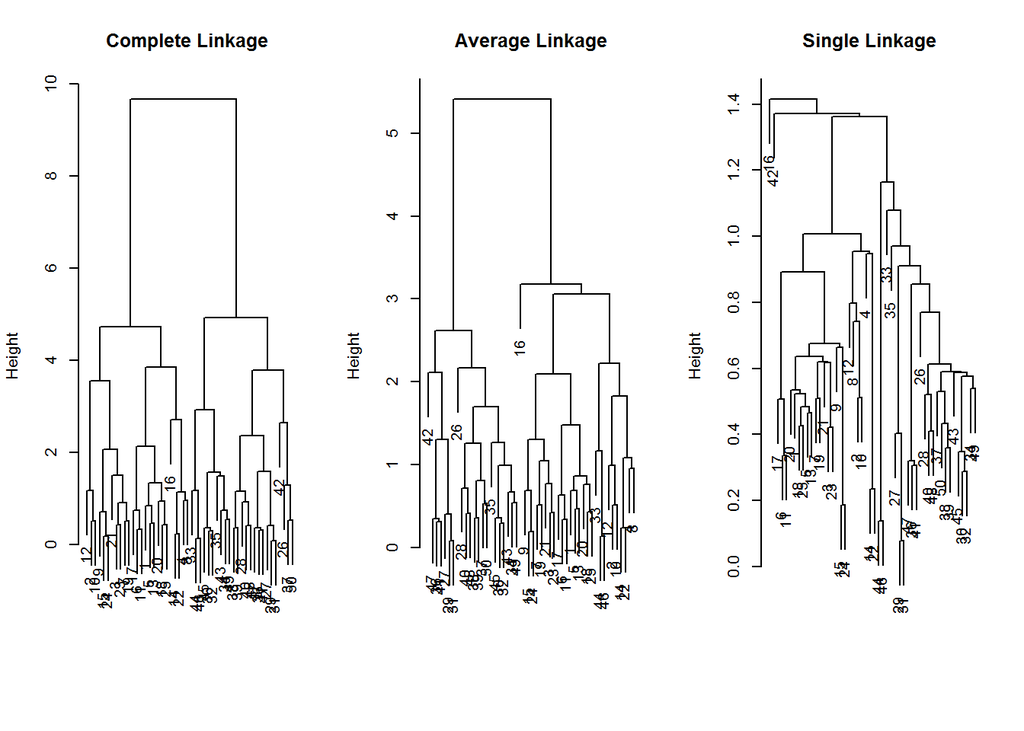

```r
par(mfrow=c(1,3)) #plot 3 graphs in 1 row
plot(hc.complete ,main="Complete Linkage ", xlab="", sub ="", cex=.9)
plot(hc.average , main="Average Linkage", xlab="", sub ="", cex=.9)
plot(hc.single , main="Single Linkage ", xlab="", sub ="", cex=.9)
```

```r
par(mfrow=c(1,1)) #set the graph options back to default
```

To determine the cluster labels for each observation associated with a given cut of the dendrogram, we can use the cutree() function:

```r
cutree(hc.complete , 2)
```

```
##  [1] 1 1 1 1 1 1 1 1 1 1 1 1 1 1 1 1 1 1 1 1 1 1 1 1 1 2 2 2 2 2 2 2 2 2 2
## [36] 2 2 2 2 2 2 2 2 2 2 2 2 2 2 2
```

```r
cutree(hc.average , 2)
```

```
##  [1] 1 1 1 1 1 1 1 1 1 1 1 1 1 1 1 1 1 1 1 1 1 1 1 1 1 2 2 2 2 2 2 2 1 2 2
## [36] 2 2 2 2 2 2 2 2 1 2 1 2 2 2 2
```

```r
cutree(hc.single , 2)
```

```
##  [1] 1 1 1 1 1 1 1 1 1 1 1 1 1 1 1 2 1 1 1 1 1 1 1 1 1 1 1 1 1 1 1 1 1 1 1
## [36] 1 1 1 1 1 1 1 1 1 1 1 1 1 1 1
```

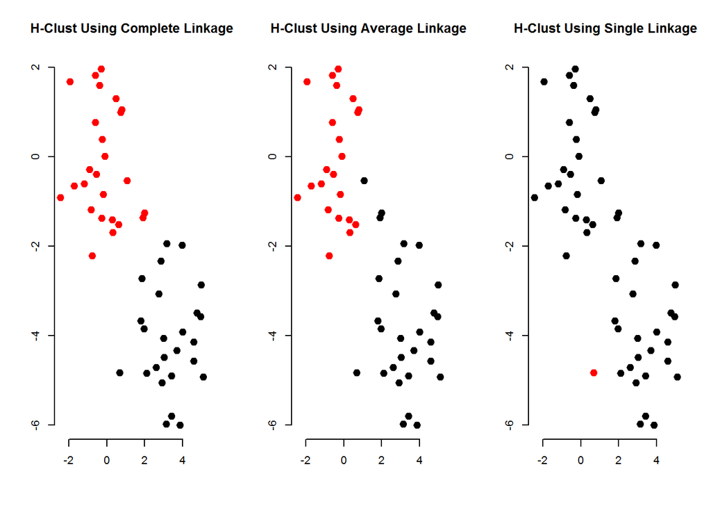

```r
par(mfrow = c(1,3))

plot(x,
     col = cutree(hc.complete , 2) ,
main="H-Clust Using Complete Linkage",
xlab ="",
ylab="",
pch =20,
cex = 2,
bty = "n")


plot(x,
     col = cutree(hc.average , 2) ,
main="H-Clust Using Average Linkage",
xlab ="",
ylab="",
pch =20,
cex = 2,
bty = "n")


plot(x,
     col = cutree(hc.single , 2) ,
main="H-Clust Using Single Linkage",
xlab ="",
ylab="",
pch =20,
cex = 2,
bty = "n")
```

```r
par(mfrow = c(1,1))
```

For this data, complete and average linkage generally separate the observations into their correct groups. However, single linkage identifies one point as belonging to its own cluster. A more sensible answer is obtained when four clusters are selected, although there are still two singletons.

```r
cutree(hc.single , 4)
```

```
##  [1] 1 1 1 1 1 1 1 1 1 1 1 1 1 1 1 2 1 1 1 1 1 1 1 1 1 3 3 3 3 3 3 3 3 3 3
## [36] 3 3 3 3 3 3 4 3 3 3 3 3 3 3 3
```

To scale the variables before performing hierarchical clustering of the observations, we use the scale() function:

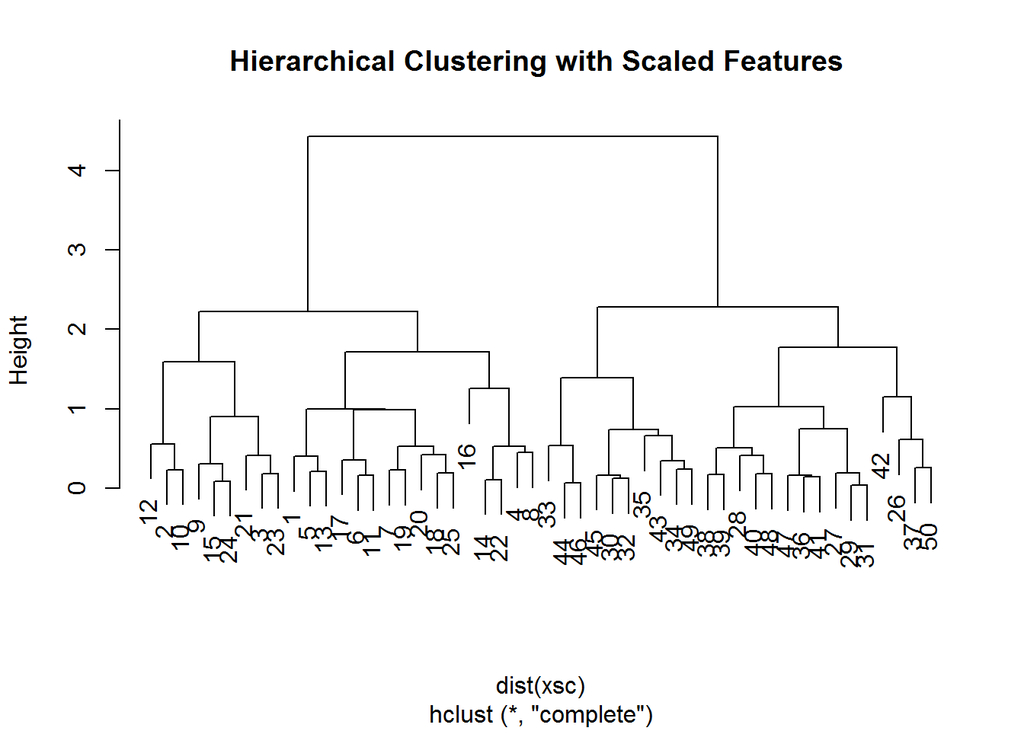

```r
xsc <- scale(x)

plot(hclust(dist(xsc),
     method ="complete"),
     main="Hierarchical Clustering with Scaled Features ")
```

To compare with unscaled version:

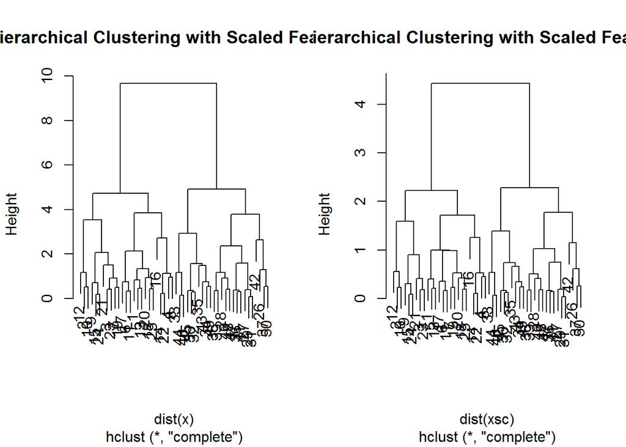

```r
par(mfrow = c(1,2))

plot(hc.complete,main = "Hierarchical Clustering with Scaled Features")

plot(hclust(dist(xsc),
     method ="complete"),
     main="Hierarchical Clustering with Scaled Features")
```

```r
par(mfrow = c(1,1))
```

Here, scaling does not seem to make much of a difference. However, when variables are measured on different scales, we will likely want to standardize the data before proceeding.

We now turn to a more substantial example, using the Immoscout example data

# Exercise clustering on immo scout fr data

Load the data as usual.

```r
rm(list = ls())

load("immofr_extended.Rda")

head(fr_immo)
```

```
##                                                      place rent     m2
## 1     Olof-Palme-Straße 31, Heddernheim, Frankfurt am Main  485  20.74
## 2      Lise-Meitner-Str. 16, Bockenheim, Frankfurt am Main 1959 123.00
## 3                Westring 22, Praunheim, Frankfurt am Main 1150 100.35
## 4 Mainzer Landstraße 231, Gallusviertel, Frankfurt am Main  899  21.00
## 5 Mainzer Landstraße 385, Gallusviertel, Frankfurt am Main   NA     NA
## 6              Rhonestraße 2, Niederrad, Frankfurt am Main 1200  75.40
##   rooms      lon      lat     quarter kita_number number_doctors
## 1     1 8.641285 50.17283 Heddernheim          20             42
## 2     3 8.639105 50.11581  Bockenheim          46            104
## 3     4 8.614095 50.13362   Praunheim           9             18
## 4     1 8.647639 50.10428      Gallus          22             43
## 5    NA 8.631516 50.10180      Gallus          22             43
## 6     2 8.625571 50.08153   Niederrad          16             28
##   unemployment_rate voteshare voteshare_cdu voteshare_spd voteshare_afd
```

[output cut: 20 more lines]

We remove the character variables the data as usual:

```r
fr_immo_reduced <- dplyr::select(fr_immo, -"place", -"lon", -"lat", -"quarter", -"frank_lat", -"frank_lon") #we remove the address, the quarter, and the lon and lat

fr_immo_reduced <- na.omit(fr_immo_reduced) #drop NAs from data set
```

## K-means clustering for Immoscout data

We start with applying k-means clustering to the Immoscout data. In the first step, we need to scale the data.

```r
# scaling the variables
fr_immo_reduced_scaled <- scale(fr_immo_reduced)
```

In the second step, k-means requires us to pre-specify the desired number of clusters.

```r
# K-Means Cluster Analysis
k.means.immo10 <- kmeans(fr_immo_reduced_scaled,
                       10, # 10 clusters
                       nstart = 50) # ensure that atleat 50 random sets are choosen
```

We can use the elbow method to obtain an intutition for the optimal number of clusters. The elbow method looks at the percentage of variance explained as a function of the number of clusters: One should choose a number of clusters so that adding another cluster doesn’t give much better modeling of the data.

The total within-cluster sum of squares (WSS) measures the compactness of the clustering and we want it to be as small as possible. The Elbow method looks at the total WSS as a function of the number of clusters: One should choose a number of clusters so that adding another cluster doesn’t improve much better the total WSS. This is then the “elbow criterion”. This “elbow” cannot always be unambiguously identified.

In R, an easy way to obtain the elbow plot is using the factoextra package:

```r
library(factoextra)
```

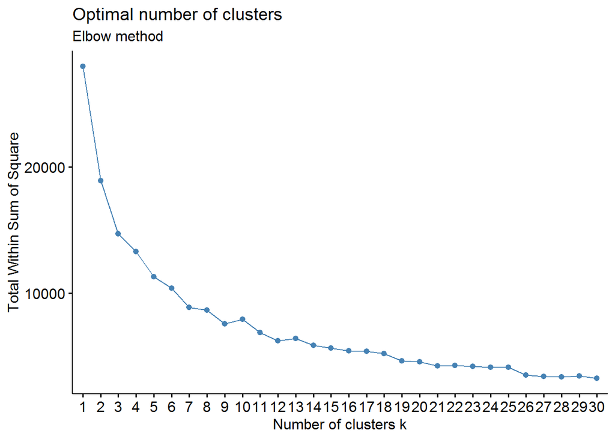

```r
fviz_nbclust(fr_immo_reduced_scaled, #data set we want to use
             kmeans, #cluster method
             method = "wss", #method used for estimating the optimal number of clusters. "wss" =  total within sum of square
             k.max = 30) +
labs(subtitle = "Elbow method")
```

In this case, there is no unambiguous elbow. There are additional methods available to validate cluster solutions such as the **average silhouette** approach or the **gap statistic**, but these methods would be well beyond this short introduction.

However, there exists another visual method to inspect the cluster solution: clusplots (Pison et al. 1999). The clusplot uses PCA to draw the data. It uses the first two principal components (as a dimension reduction of the data) to plot the observations including their cluster assignments. We plot the initial k-means cluster with k = 10 using the e-clust function

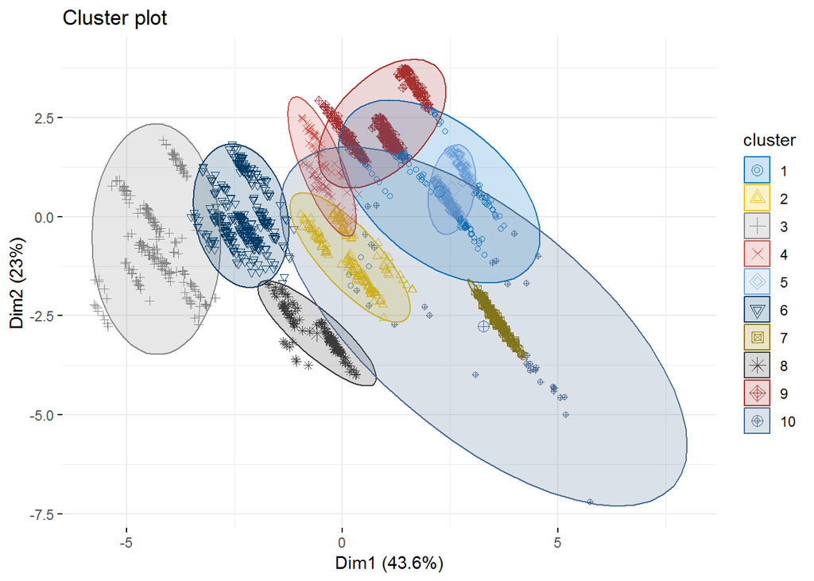

```r
# K-means clustering with eclust: create an eclust object, which is a wrapup function for different cluster methods

km.res.10 <- eclust(fr_immo_reduced_scaled, "kmeans", k = 10, nstart = 50, graph = FALSE)

# Visualize k-means clusters
fviz_cluster(km.res.10, geom = "point", ellipse.type = "norm",
             palette = "jco", ggtheme = theme_minimal())
```

We see that we need more clusters. We thus rerun the k-means with a higher k. We know that we have around 40 different city districts in our data (something we would not know normally). Thus, we set K = 40.

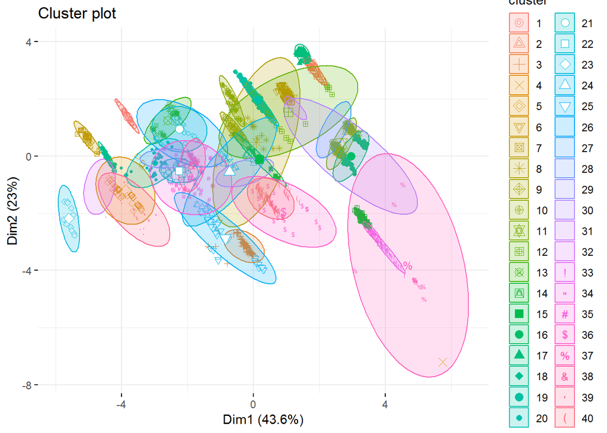

```r
km.res.40 <- eclust(fr_immo_reduced_scaled, "kmeans", k = 40, nstart = 50, graph = FALSE)

# Visualize k-means clusters
fviz_cluster(km.res.40, geom = "point", ellipse.type = "norm", ggtheme = theme_minimal())
```

This looks a bit better, although we overfit a little. Let’s assign the two cluster solutions to the original data.

Because we have spatial data, there is a better, and more intuitive way to validate the cluster solutions: plotting the observations with their cluster assignments on a map.

```r
#require(ggmap)
#ATTENTION: ggmap requires a google account and getting a google API. This code is only shown to give you guidance.
#see https://rdrr.io/github/dkahle/ggmap/man/register_google.html to get more information about registering for
#ggmaps

# append cluster assignment

#fr_immo_reduced$kmeans10 <- as.factor(km.res.10$cluster)
#fr_immo_reduced$kmeans40 <- as.factor(km.res.40$cluster)

#plot the kmeans 10 solution using ggmap
#
# qmap("Frankfurt",
#      zoom = 12,
#      maptype="hybrid"
#      ) +
#
#   geom_point(aes(x=lon,
#                  y=lat,
#                  color = kmeans10
#                  ),
#              data=fr_immo,
#              size=2)
#
# #plot kmeans40 cluster solution
#
# qmap("Frankfurt",
#      zoom = 12,
#      maptype="hybrid")+
#
#   geom_point(aes(x=lon,
#                  y=lat,
#                  color = kmeans40
#                  ),
#              data=fr_immo,
#              size=2)
#
# #first cluster solution with different map to see more
#
# pdf("kmeansimmo10_tonerlite.pdf")
#
# qmap("Frankfurt",
#      zoom = 11,
#      maptype="toner-lite" #changing the map type
#      ) +
#
#   geom_point(aes(x=lon,
#                  y=lat,
#                  color = kmeans10
#                  ),
#              data=fr_immo,
#              size=1)
#
# dev.off()
#
# #doing the same for k=40 solution
#
# pdf("kmeansimmo40_tonerlite.pdf")
#
# qmap("Frankfurt",
#      zoom = 11,
#      maptype="toner-lite" #changing the map type
#      ) +
#
#   geom_point(aes(x=lon,
#                  y=lat,
#                  color = kmeans40
#                  ),
#              data=fr_immo,
#              size=1)
#
# dev.off()
```

## Immoscout Frankfurt H-clust

We now turn to apply hierarchical clustering to the same data set.

```r
hclust.immo <- hclust(dist(fr_immo_reduced_scaled), method="complete")
```

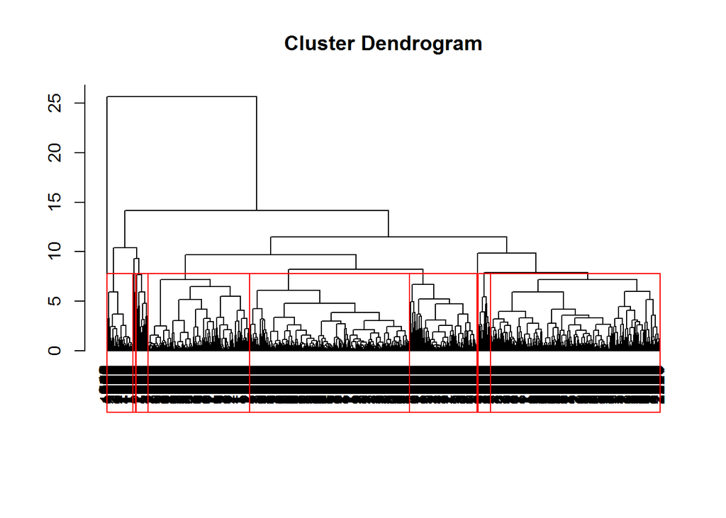

```r
# display dendogram
plot(hclust.immo,
            xlab="",
            ylab= "",
            sub="",
            hang = -1) #labels all on the same level

# draw dendogram with red borders around the 10 clusters
rect.hclust(hclust.immo,
            k=10,
            border="red")
```

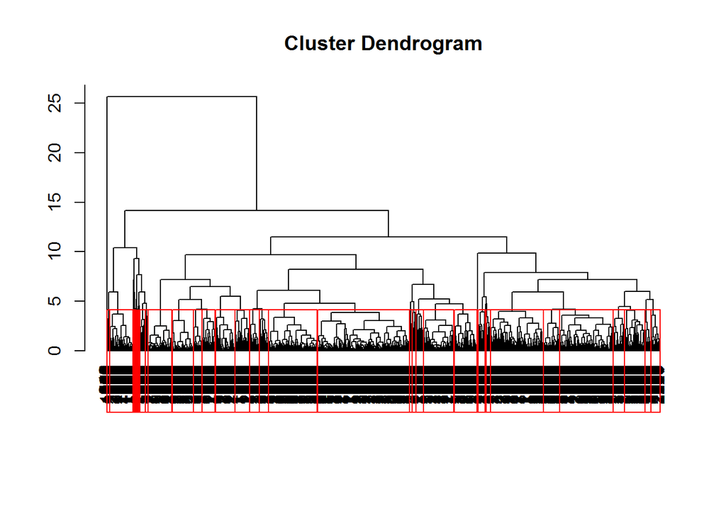

```r
#with more clusters:

# display dendogram
plot(hclust.immo,
            xlab="",
            ylab= "",
            sub="",
            hang = -1) #labels all on the same level

# draw dendogram with red borders around the 40 clusters
rect.hclust(hclust.immo,
            k=40,
            border="red")
```

We can of course use the same cluster validation methods as before. Here, we use eclust and fviz_cluster again.

```
## Too few points to calculate an ellipse
## Too few points to calculate an ellipse
```

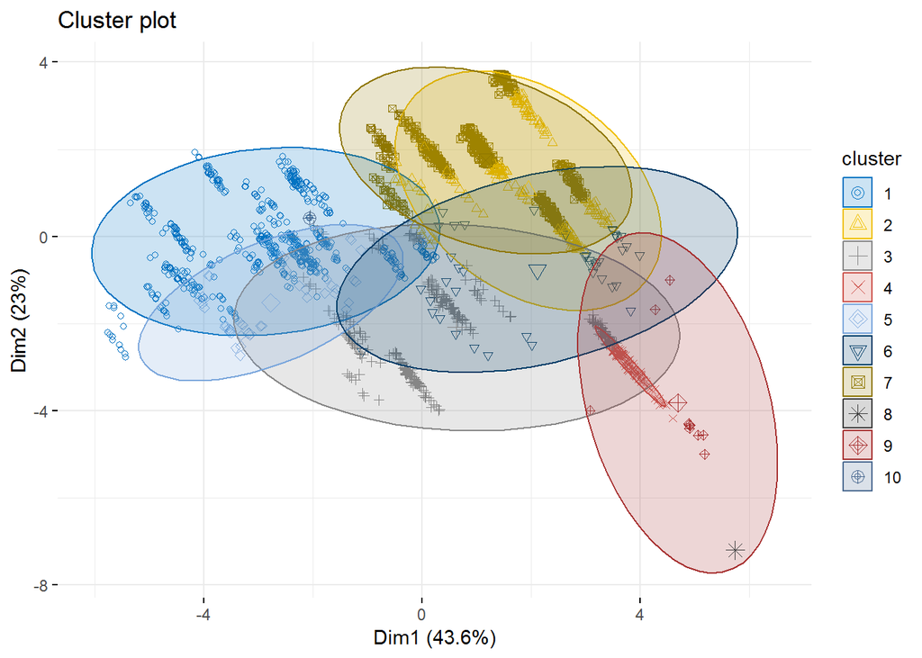

```r
hc.res <- eclust(fr_immo_reduced_scaled, "hclust", k = 10,
                 hc_metric = "euclidean",
                 hc_method = "complete",
                 graph = FALSE)

fviz_cluster(hc.res, geom = "point", ellipse.type = "norm",
             palette = "jco", ggtheme = theme_minimal())
```

Finally, we quickly look at clustering as a feature engeneering step.

## Clustering as pre-processing step

Use found kmeans (k = 10) cluster solution as an additional feature for the rpart prediction of rent.

```r
require(caret)
#append kmeans solution and change to factor
fr_immo_reduced$kmeans10 <- as.factor(km.res.10$cluster)

## Split data in training and test set
set.seed(7345)

split_index <- sample(1:nrow(fr_immo_reduced), 0.8*nrow(fr_immo_reduced))
fr_test <- fr_immo_reduced[-split_index,]
fr_train <- fr_immo_reduced[split_index,]


#Run RF on a model not including the cluster assignments and including it
set.seed(1234)
rpart.immo <- train(rent ~ m2 + rooms + dist_to_center,
                      method = "rpart",
                      fr_train
                          )
rpart.immo$results
```

```
##          cp     RMSE  Rsquared      MAE   RMSESD RsquaredSD    MAESD
## 1 0.1041689 655.2828 0.5226053 412.0598 112.5993 0.09159805 37.50032
## 2 0.1178787 675.7191 0.4951477 432.5116 121.8951 0.08433539 29.72208
## 3 0.4252357 813.1086 0.3727621 504.6618 134.4307 0.06505420 51.62450
```

```r
# predict the outcome on a test set
rpart_immopredict <- predict(rpart.immo, fr_test)

#Estimate RMSE, R^2 and MAE:

postResample(pred = rpart_immopredict, obs = fr_test$rent)
```

```
##        RMSE    Rsquared         MAE
## 646.3138109   0.3753935 418.0868631
```

```r
#rpart with cluster solution

set.seed(1234)
rpart.immo.kmeans <- train(rent ~ m2 + rooms + dist_to_center + kmeans10,
                      method = "rpart",
                      fr_train
                          )
rpart.immo.kmeans$results
```

```
##          cp     RMSE  Rsquared      MAE    RMSESD RsquaredSD    MAESD
## 1 0.1041689 620.2266 0.5835356 395.7731  84.48863 0.05088325 29.29293
## 2 0.1232808 654.3793 0.5324239 425.3967 116.97149 0.10294886 35.60822
## 3 0.4252357 805.4170 0.3645098 502.4067 133.93623 0.07004399 45.94379
```

```r
# predict the outcome on a test set

rpart_immopredict_kmeans <- predict(rpart.immo.kmeans, fr_test)

#Estimate RMSE, R^2 and MAE:

postResample(pred = rpart_immopredict_kmeans, obs = fr_test$rent)
```

```
##        RMSE    Rsquared         MAE
## 541.9392197   0.5550079 392.5840120
```